# phyloseq_2_Example Data in phyloseq

wentao

2019/8/23

# phyloseq示例

**Example Data in phyloseq**

ggplot2包主题设置。更多帮助，请参阅ggplot2联机文档。

> ggplot2 package theme set. See the ggplot2 online documentation for further help.

```r
library("phyloseq"); packageVersion("phyloseq")
```

```
## [1] '1.28.0'
```

```r
library("ggplot2"); packageVersion("ggplot2")
```

```
## [1] '3.2.0'
```

```r
theme_set(theme_bw())
```

phyloseq中自带有多份数据，许多来自发表的文献 >There are multiple example data sets included in phyloseq. Many are from published investigations and include documentation with a summary and references, as well as some example code representing some aspect of analysis available in phyloseq.

data()函数将数据载入到R的环境中。

> To load example data into the working environment, use the data() command:

```r
#使用phyloseq
data(GlobalPatterns)
data(esophagus)
data(enterotype)
data(soilrep)
```

### 文档

**Documentation**

在包索引目录中，转到以“data”开头的名称以查看当前可用示例数据集的文档。

> In the package index, go to the names beginning with “data-” to see the documentation of currently available example datasets.

查看GlobalPatterns数据介绍

浏览GlobalPatterns数据集

> to access the documentation for the so-called “GlobalPatterns” dataset

#### 调用数据：测试一个例子文件

*Run provided examples*

可以使用r中的example命令来展示示例数中包含的例子（以及函数/方法的示例），在本例中是enterotype数据集

> You can also try the examples included with the example data documentation (as well as examples for functions/methods) using the standard example command in R – in this case the examples for the enterotype dataset

```r
example(enterotype, ask=FALSE)
```

```
##
## entrty> data(enterotype)
##
## entrty> ig <- make_network(enterotype, "samples", max.dist=0.3)
##
## entrty> plot_network(ig, enterotype, color="SeqTech", shape="Enterotype", line_weight=0.3, label=NULL)
```

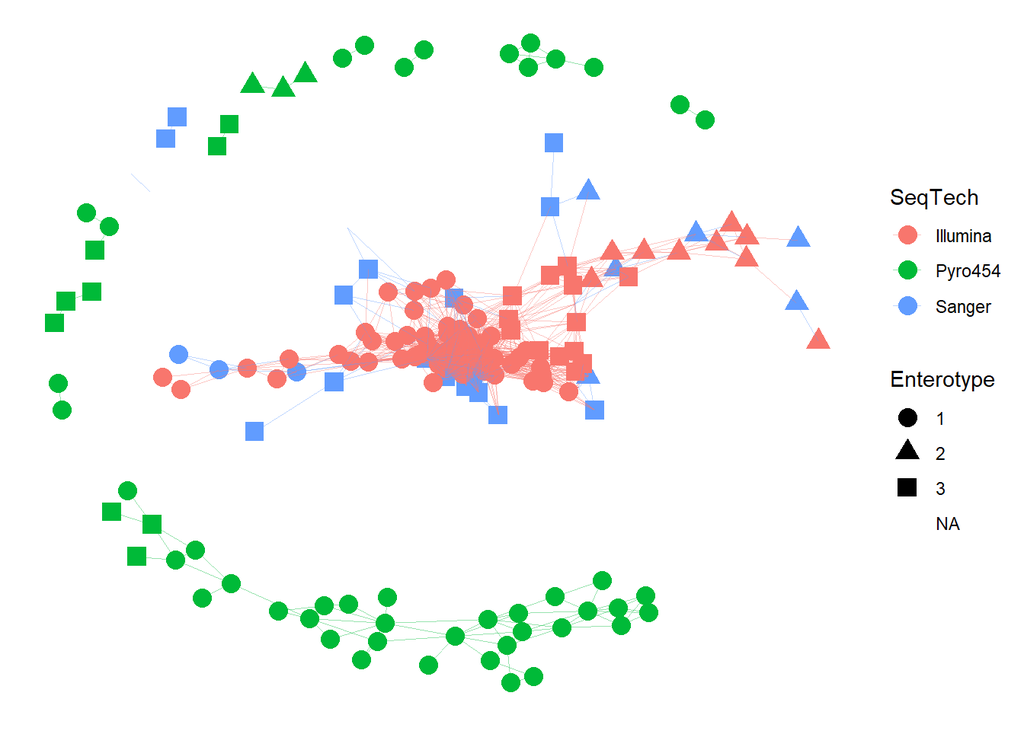

```r
# ?example
```

example 命令拆分，即为一下三条命令

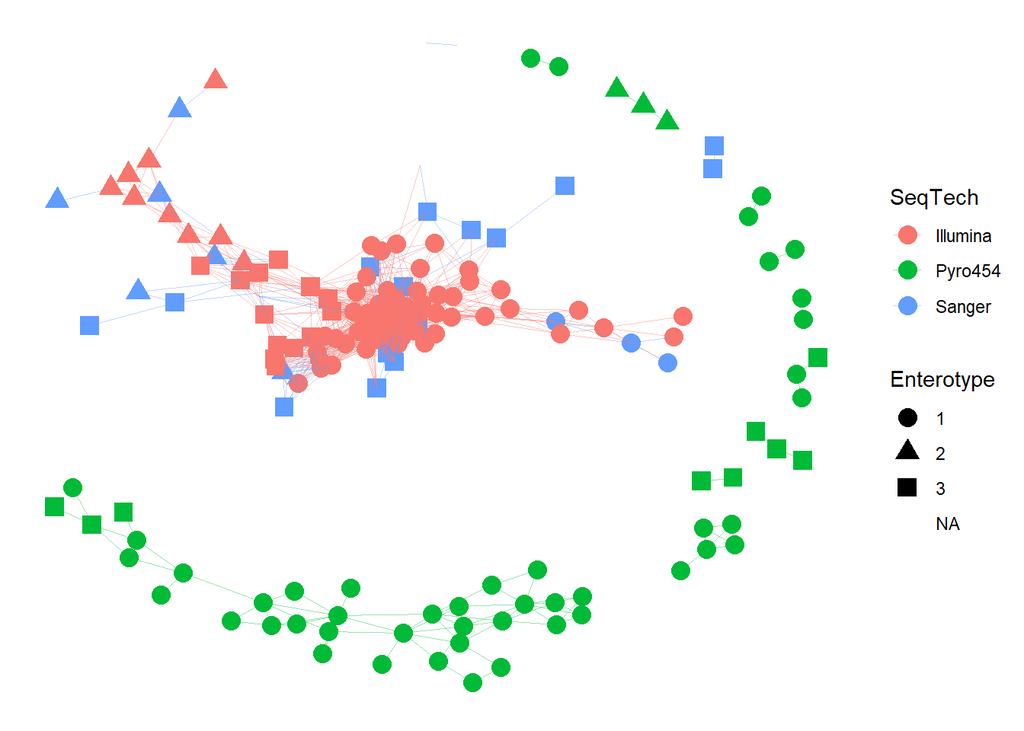

```r
data(enterotype)
ig <- make_network(enterotype, "samples", max.dist=0.3)

plot_network(ig, enterotype, color="SeqTech", shape="Enterotype", line_weight=0.3, label=NULL)
```

### reference

https://joey711.github.io/phyloseq/Example-Data.html